# Lab 9

Skyler Moomey

2020-10-28

# Tasks

## Task 1

```r
getwd()
```

```
## [1] "C:/Users/skyle/Documents/Statistics/Laboratories/Lab 9"
```

## Task 2

### Line A

Line A creates a random sample with replacement of size $n*iter$, from the set $x$. This means that there will be a long vector, with every $n$ elements in the vector representing one, of $iter$, samples. Additionally, sampling with replacement ensures that each random outcome will be independent of all others.

### Line B

Line B calls the quantile function on $xstat$, which is a vector of length $iter$. It contains, by default, the mean value of each $iter$ random samples. By supplying quantile with a sequence of bounds created from $\alpha$, we create a confidence interval that ensures that $\mu$ will have a $(1 - \alpha)*100 \%$ chance of lying in the interval.

### sample()

Sample must be called with replacement, otherwise the random sample collected of size $n$ would not be able to accomodate $n*iter$ unique values being drawn from it.

### commands

```r
set.seed(35)
sam=round(rnorm(20,mean=10,sd=4),2)

#five times
for (i in 0:4)
{
unique(sample(sam,20,replace=TRUE))
}

#five times
for (i in 0:4)
{
unique(sample(sam,20,replace=FALSE))
}
```

The line `sample(sam,21,replace=FALSE)` cannot run because the sam is not large enough to collect a sample of 21 elements without replacement.

## Task 3

### myboot(), 95% confidence interval, mean

```r
myboot<-function(iter=10000,x,fun="mean",alpha=0.05,...){

#Notice where the ... is repeated in the code
n=length(x)   #sample size

#Now sample with replacement
y=sample(x,n*iter,replace=TRUE) #A

# Make a matrix with all the resampled values
rs.mat=matrix(y,nr=n,nc=iter,byrow=TRUE)
xstat=apply(rs.mat,2,fun)
# xstat is a vector and will have iter values in it
ci=quantile(xstat,c(alpha/2,1-alpha/2)) #B
# Nice way to form a confidence interval
# A histogram follows
# The object para will contain the parameters used to make the histogram
para=hist(xstat,freq=FALSE,las=1,main="Histogram of Bootstrap sample statistics",...)

#mat will be a matrix that contains the data, this is done so that I can use apply()
mat=matrix(x,nr=length(x),nc=1,byrow=TRUE)

#pte is the point estimate
#This uses whatever fun is
pte=apply(mat,2,fun)
abline(v=pte,lwd=3,col="Black")# Vertical line
segments(ci[1],0,ci[2],0,lwd=4)      #Make the segment for the ci
text(ci[1],0,paste("(",round(ci[1],2),sep=""),col="Red",cex=3)
text(ci[2],0,paste(round(ci[2],2),")",sep=""),col="Red",cex=3)

# plot the point estimate 1/2 way up the density
text(pte,max(para$density)/2,round(pte,2),cex=3)

return(list(ci=ci,fun=fun,x=x))# Some output to use if necessary
}
```

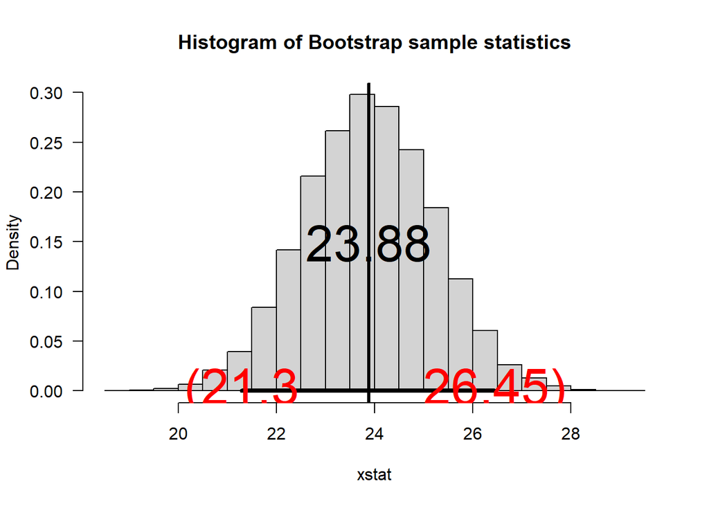

```
## $ci
##     2.5%    97.5%
## 21.29544 26.44594
##
## $fun
## [1] "mean"
##
## $x
##  [1] 23.14434 12.70757 20.72797 19.04018 29.67324 29.21639 14.78348 18.77523
##  [9] 33.37002 34.61627 26.04230 24.40206 32.03731 17.45030 19.54464 20.45388
## [17] 23.83394 30.47815 25.79640 22.67536 10.27711 26.77487 37.10044 21.59809
## [25] 22.50625
```

```r
#random sample from normal, n=25, mu=25, sigma=10
set.seed(39); sam1 = rnorm(25, 25, 10)
myboot(x=sam1)
```

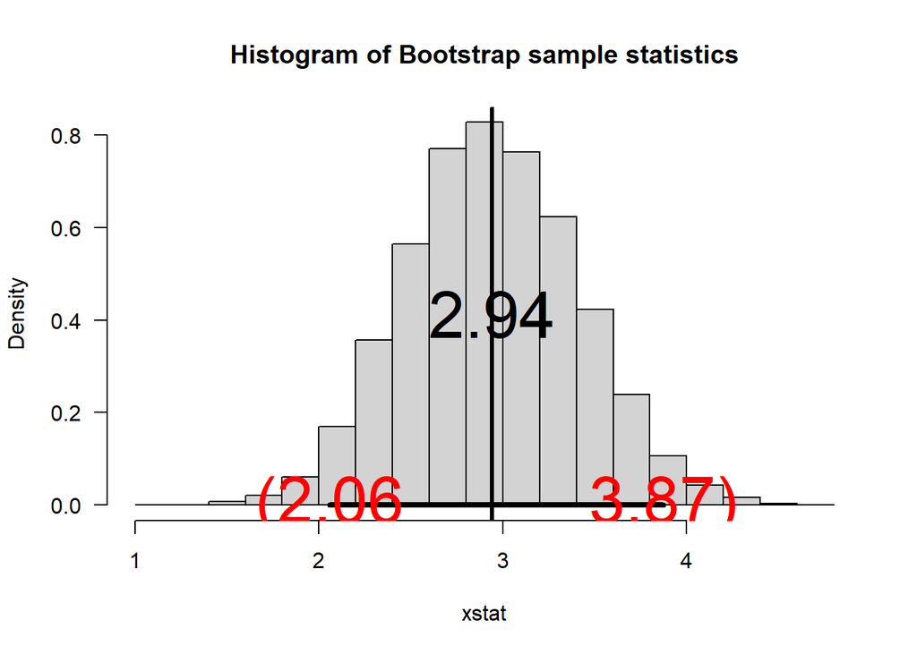

```
## $ci
##     2.5%    97.5%
## 2.058324 3.872860
##
## $fun
## [1] "mean"
##
## $x
##  [1] 0.2531032 1.6194423 5.3578133 7.3134789 0.1194100 5.0344239 5.8189991
##  [8] 4.3689673 1.6690814 3.2533362 0.9050305 2.5730754 1.9610329 2.9675027
## [15] 1.5722396 1.6959031 1.9261106 3.9198072 6.0919801 0.4082447
```

```r
#random sample from chisq, n=20, nu=3
set.seed(30); sam2=rchisq(20, df=3)
myboot(x=sam2)
```

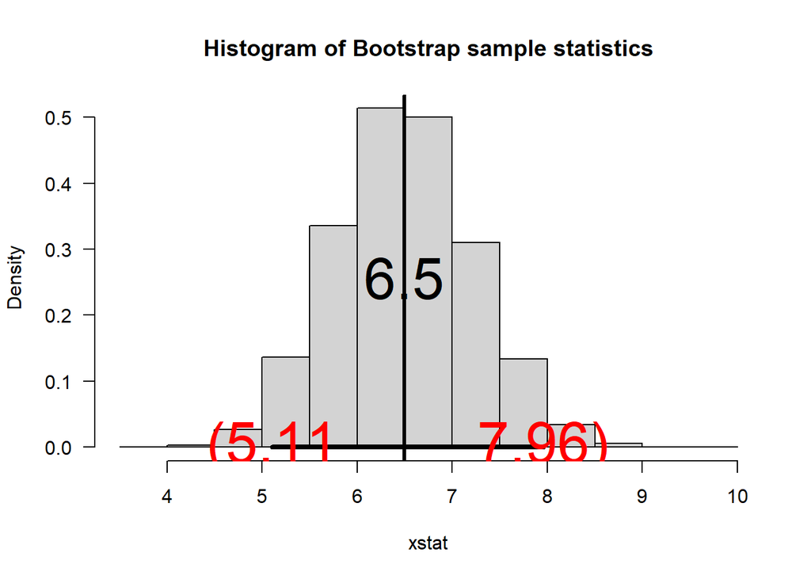

```
## $ci
##     2.5%    97.5%
## 5.109096 7.955578
##
## $fun
## [1] "mean"
##
## $x
##  [1]  6.4265012  6.5077401  1.8958495  5.3836641  1.4179366  0.7925928
##  [7]  8.0380097 14.7293204  5.2917468  2.7989621  7.9632983  2.8733832
## [13]  7.4419824  2.2828464  5.9877646 12.9354365  1.4996069  1.7478044
## [19] 12.3674161  8.4093535 10.2053201  8.0243948  6.5178039  7.9118846
## [25]  1.6924333 10.7938057  5.7341134 15.1533278  3.8545321  8.1861897
```

```r
#random sample from gamma, n=30, alpha=2. beta=3
set.seed(40); sam3=rgamma(30, shape=2, scale=3)
myboot(x=sam3)
```

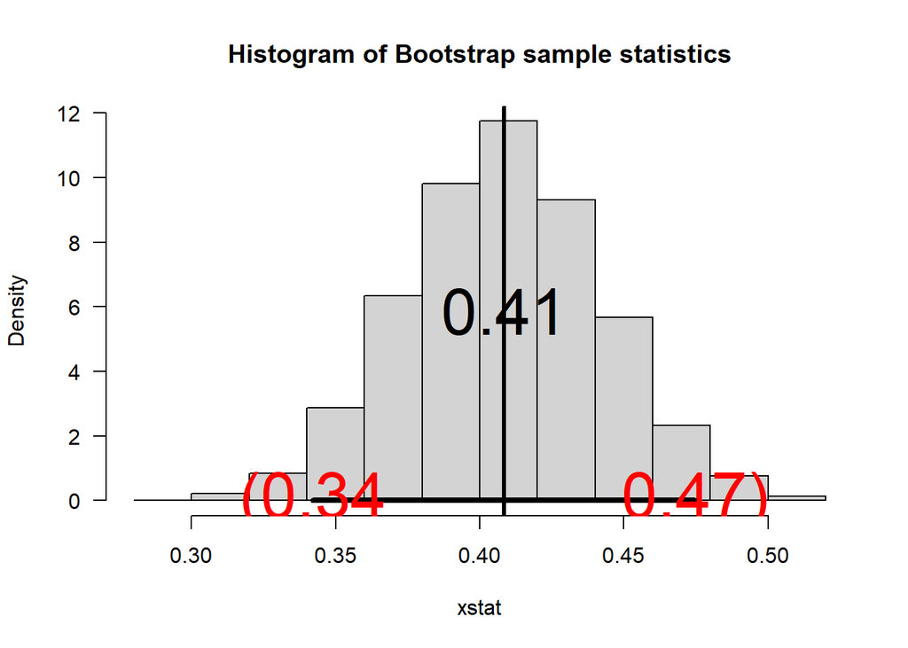

```
## $ci
##      2.5%     97.5%
## 0.3420448 0.4747873
##
## $fun
## [1] "mean"
##
## $x
##  [1] 0.4325491 0.3899825 0.1714409 0.3068918 0.4920588 0.5129946 0.1974398
##  [8] 0.3533577 0.1343329 0.3751208 0.6722481 0.5946901 0.3788602 0.6467397
## [15] 0.5914547 0.4476104 0.2407876 0.3877302 0.5336340 0.3074436
```

```r
#random sample from beta, n=20
set.seed(10); sam4=rbeta(20, shape1=3, shape2=4)
myboot(x=sam4)
```

### Chi-Square

For a Chi-Square, the point estimate created by a random sample with $n = 20$ has $\bar y = 2.94$. The true value of $\mu = \nu = 3$.

### Gamma

For a Gamma distribution, the point estimate created by a random sample with $n=30$ has $\bar y = 6.5$. The true vale of $\mu = \alpha \beta = 2*3 = 6$

### Beta

For a Beta distribution, the point estimate created by a random sample with $n=20$ has $\bar y=0.41$. The true value of $\mu = \frac{\alpha}{\alpha + \beta} = \frac{3}{3+4} = \frac{3}{7} \approx 0.4286$.

### Conclusion

In each case, the true value $\mu$ is within the 95% confidence interval.

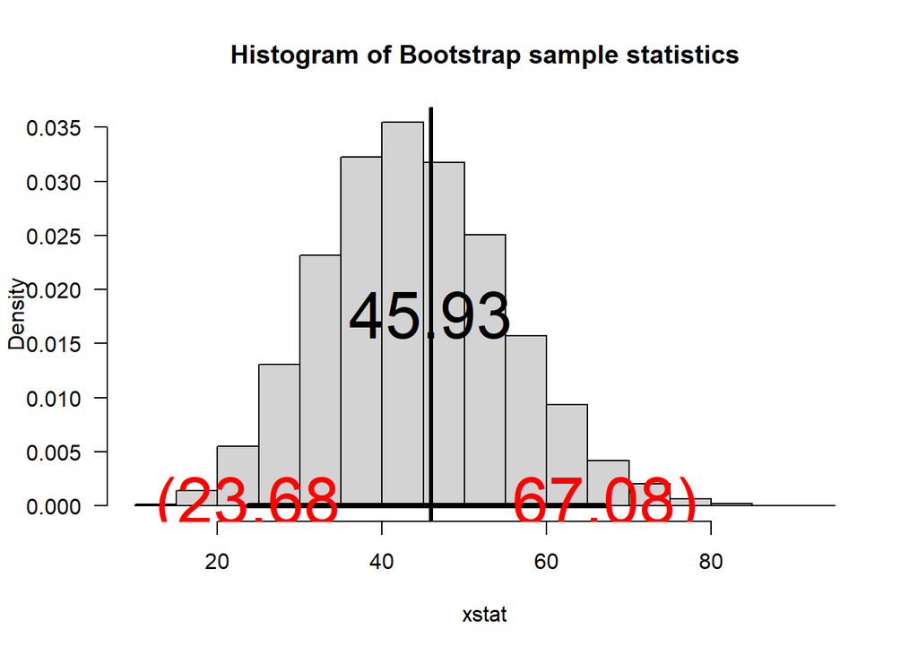

```
## $ci
##     2.5%    97.5%
## 23.67788 67.08123
##
## $fun
## [1] "var"
##
## $x
##  [1] 23.14434 12.70757 20.72797 19.04018 29.67324 29.21639 14.78348 18.77523
##  [9] 33.37002 34.61627 26.04230 24.40206 32.03731 17.45030 19.54464 20.45388
## [17] 23.83394 30.47815 25.79640 22.67536 10.27711 26.77487 37.10044 21.59809
## [25] 22.50625
```

```r
set.seed(39); sam1 = rnorm(25, 25, 10)
myboot(x=sam1, fun="var")
```

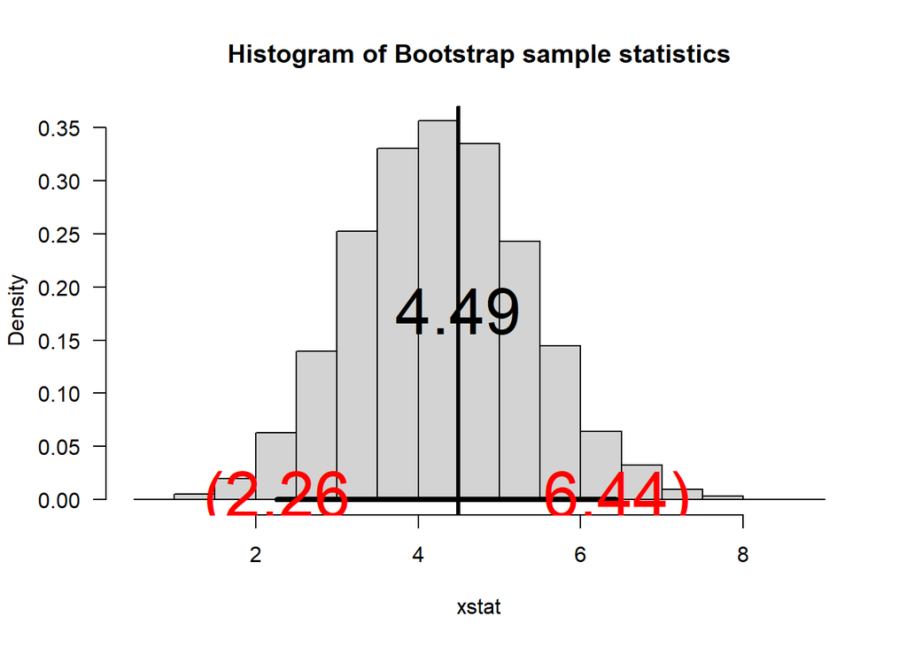

```
## $ci
##     2.5%    97.5%
## 2.258782 6.442664
##
## $fun
## [1] "var"
##
## $x
##  [1] 0.2531032 1.6194423 5.3578133 7.3134789 0.1194100 5.0344239 5.8189991
##  [8] 4.3689673 1.6690814 3.2533362 0.9050305 2.5730754 1.9610329 2.9675027
## [15] 1.5722396 1.6959031 1.9261106 3.9198072 6.0919801 0.4082447
```

```r
#random sample from chisq, n=20, nu=3
set.seed(30); sam2=rchisq(20, df=3)
myboot(x=sam2, fun="var")
```

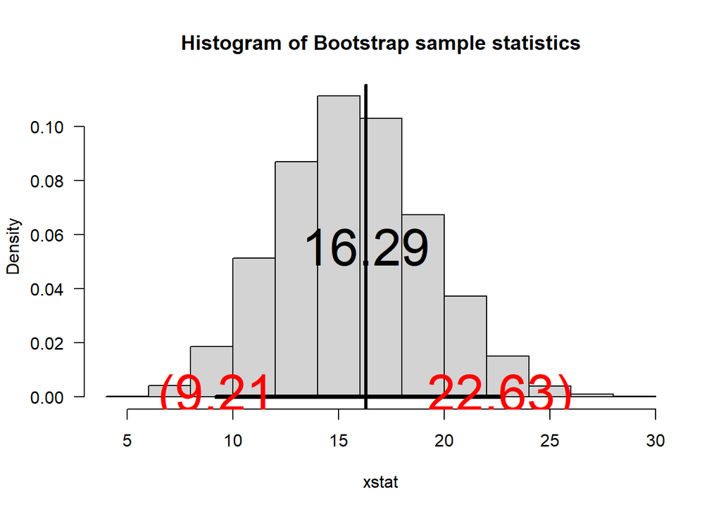

```
## $ci
##      2.5%     97.5%
##  9.210123 22.633631
##
## $fun
## [1] "var"
##
## $x
##  [1]  6.4265012  6.5077401  1.8958495  5.3836641  1.4179366  0.7925928
##  [7]  8.0380097 14.7293204  5.2917468  2.7989621  7.9632983  2.8733832
## [13]  7.4419824  2.2828464  5.9877646 12.9354365  1.4996069  1.7478044
## [19] 12.3674161  8.4093535 10.2053201  8.0243948  6.5178039  7.9118846
## [25]  1.6924333 10.7938057  5.7341134 15.1533278  3.8545321  8.1861897
```

```r
#random sample from gamma, n=30, alpha=2. beta=3
set.seed(40); sam3=rgamma(30, shape=2, scale=3)
myboot(x=sam3, fun="var")
```

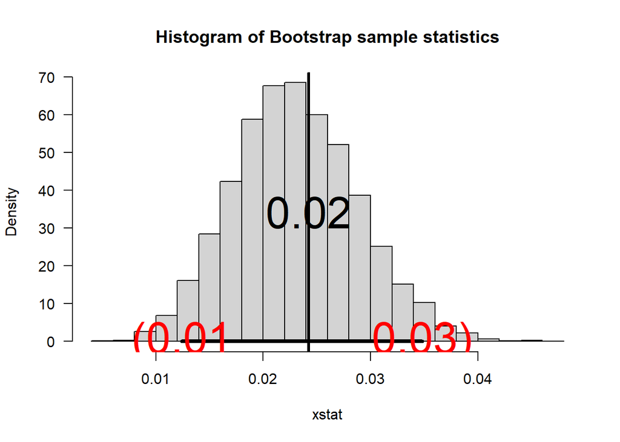

```
## $ci
##       2.5%      97.5%
## 0.01241445 0.03481951
##
## $fun
## [1] "var"
##
## $x
##  [1] 0.4325491 0.3899825 0.1714409 0.3068918 0.4920588 0.5129946 0.1974398
##  [8] 0.3533577 0.1343329 0.3751208 0.6722481 0.5946901 0.3788602 0.6467397
## [15] 0.5914547 0.4476104 0.2407876 0.3877302 0.5336340 0.3074436
```

```r
#random sample from beta, n=20
set.seed(10); sam4=rbeta(20, shape1=3, shape2=4)
myboot(x=sam4, fun="var")
```

## Task 4

### Adjusted myboot()

```r
myboot<-function(iter=10000,x,fun="mean",alpha=0.05,...){

#Notice where the ... is repeated in the code
n=length(x)   #sample size

#Now sample with replacement
y=sample(x,n*iter,replace=TRUE) #A

# Make a matrix with all the resampled values
rs.mat=matrix(y,nr=n,nc=iter,byrow=TRUE)
xstat=apply(rs.mat,2,fun)
# xstat is a vector and will have iter values in it
ci=quantile(xstat,c(alpha/2,1-alpha/2)) #B
# Nice way to form a confidence interval
# A histogram follows
# The object para will contain the parameters used to make the histogram
para=hist(xstat,freq=FALSE,las=1,main="Histogram of Bootstrap sample statistics",...)

#mat will be a matrix that contains the data, this is done so that I can use apply()
mat=matrix(x,nr=length(x),nc=1,byrow=TRUE)

#pte is the point estimate
#This uses whatever fun is
pte=apply(mat,2,fun)
abline(v=pte,lwd=3,col="Black")# Vertical line
segments(ci[1],0,ci[2],0,lwd=4)      #Make the segment for the ci
text(ci[1],0,paste("(",round(ci[1],2),sep=""),col="Red",cex=3)
text(ci[2],0,paste(round(ci[2],2),")",sep=""),col="Red",cex=3)

# plot the point estimate 1/2 way up the density
text(pte,max(para$density)/2,round(pte,2),cex=3)

return(list(xstat, ci=ci,fun=fun,x=x))# Some output to use if necessary
}
```

### sam=c(1,1,1,2,2,2,2,3,3,3,4,4)

```r
sam=c(1,1,1,2,2,2,2,3,3,3,4,4)

bootstrapstat=myboot(x=sam, fun="median")
```

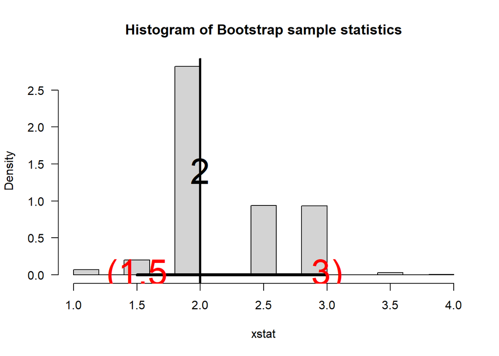

The bootstrap interval estimate is $(1.5, 3)$.

## Task 5

### 95% confidence

```r
##function to calculate mean/median, pass to myboot
mean_over_median = function(x)
{
  return (mean(x)/median(x))
}

set.seed(39); sam=rnorm(25,mean=25,sd=10)
bootstat = myboot(x=sam, fun=mean_over_median)
```

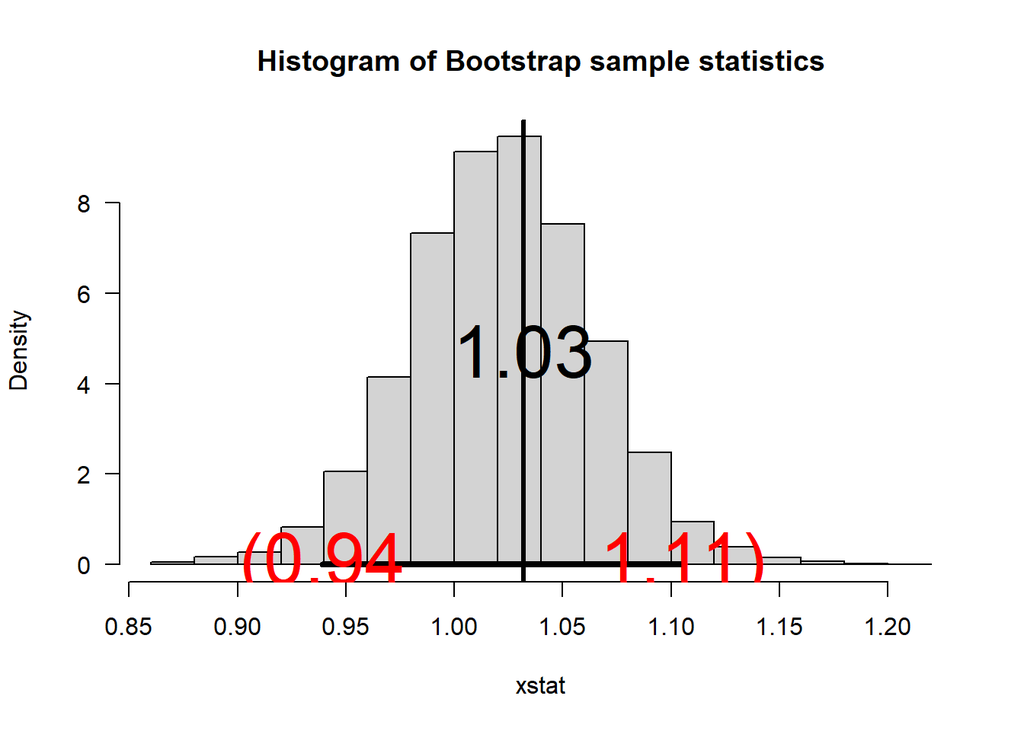

```r
set.seed(30); sam=rchisq(20,df=3)
bootstat = myboot(x=sam, fun=mean_over_median)
```

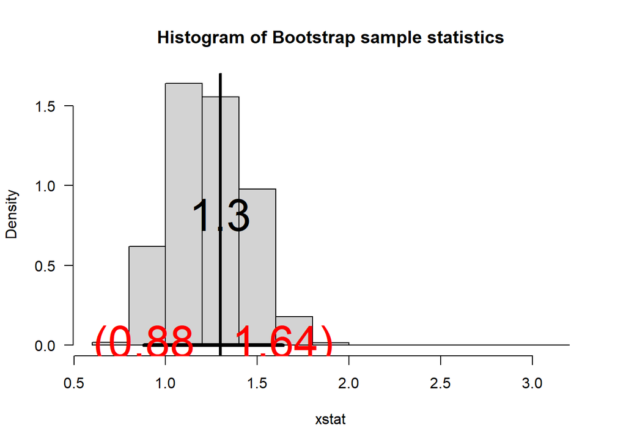

```r
set.seed(40); sam=rgamma(30,shape=2,scale=3)
bootstat = myboot(x=sam, fun=mean_over_median)
```

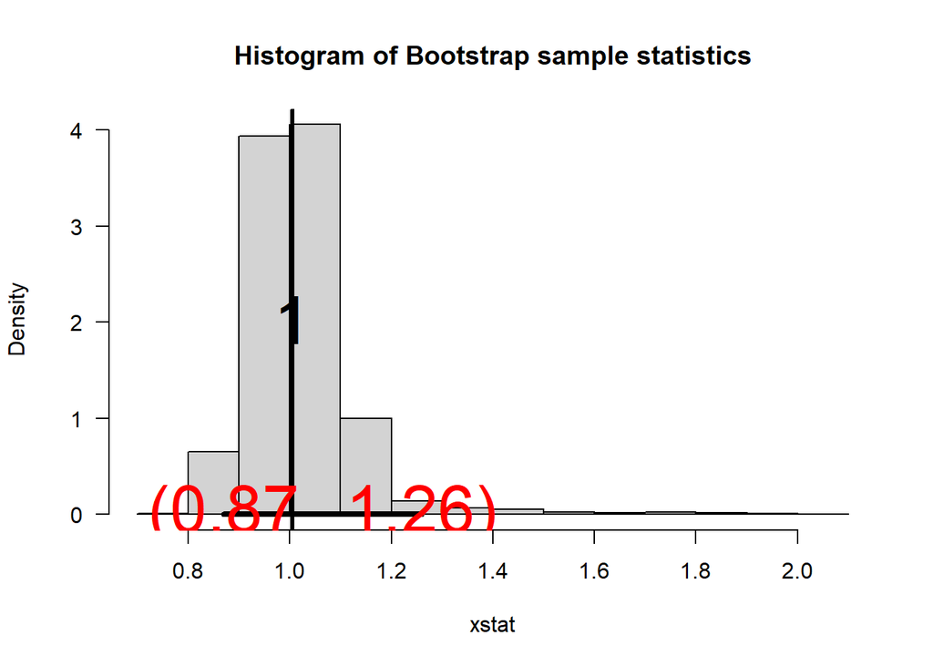

```r
set.seed(10); sam=rbeta(20,shape1=3,shape2=4)
bootstat = myboot(x=sam, fun=mean_over_median)
```

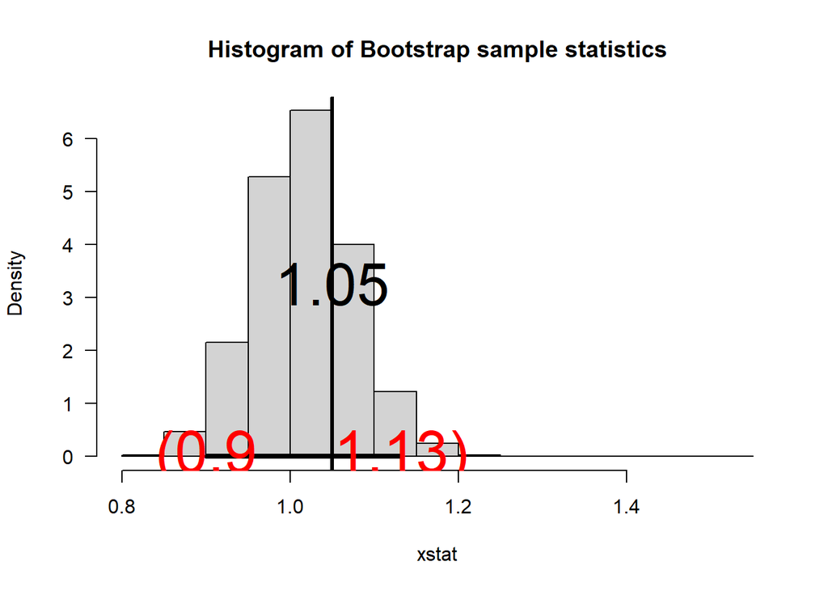

### 70% confidence

```r
set.seed(39); sam=rnorm(25,mean=25,sd=10)
bootstat = myboot(x=sam, fun=mean_over_median, alpha=.3)
```

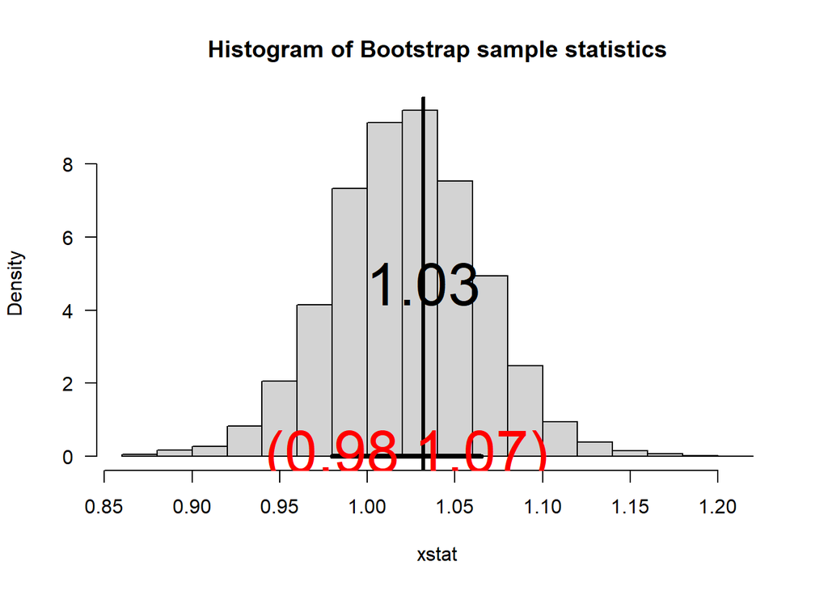

```r
set.seed(30); sam=rchisq(20,df=3)
bootstat = myboot(x=sam, fun=mean_over_median, alpha=.3)
```

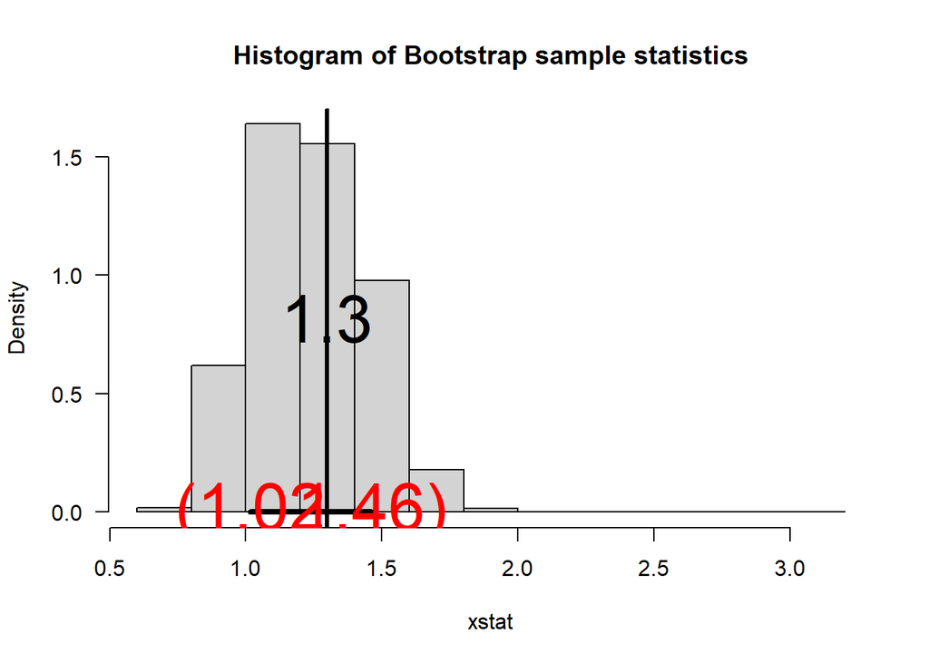

```r
set.seed(40); sam=rgamma(30,shape=2,scale=3)
bootstat = myboot(x=sam, fun=mean_over_median, alpha=.3)
```

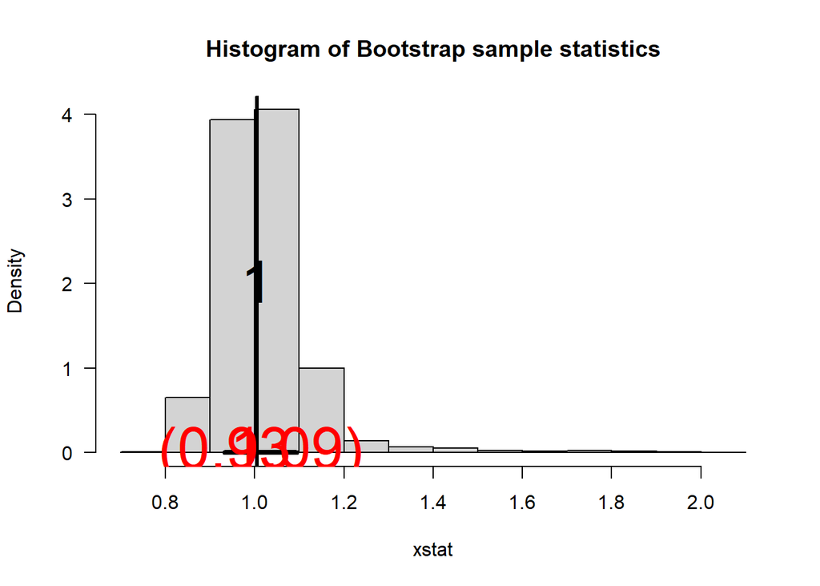

```r
set.seed(10); sam=rbeta(20,shape1=3,shape2=4)
bootstat = myboot(x=sam, fun=mean_over_median, alpha=.3)
```

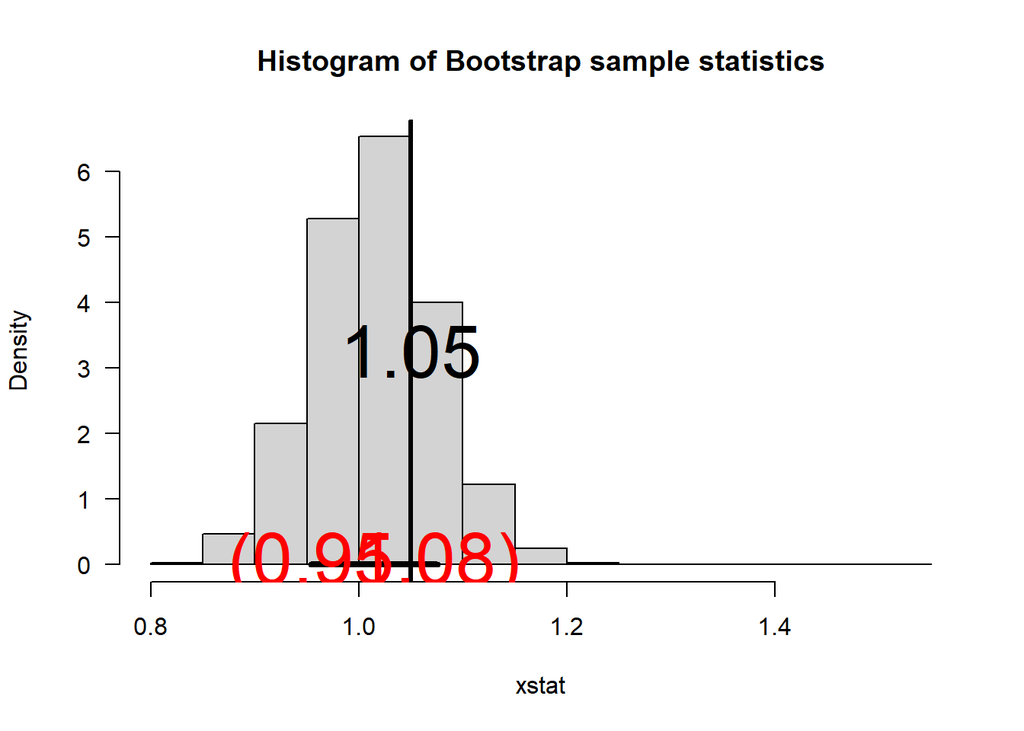

## Task 6

### Uniform Distribution

```r
set.seed(1); sam=runif(20, min=0, max = 10)
bootstat=myboot(x=sam, fun="mean", alpha=.2)
```

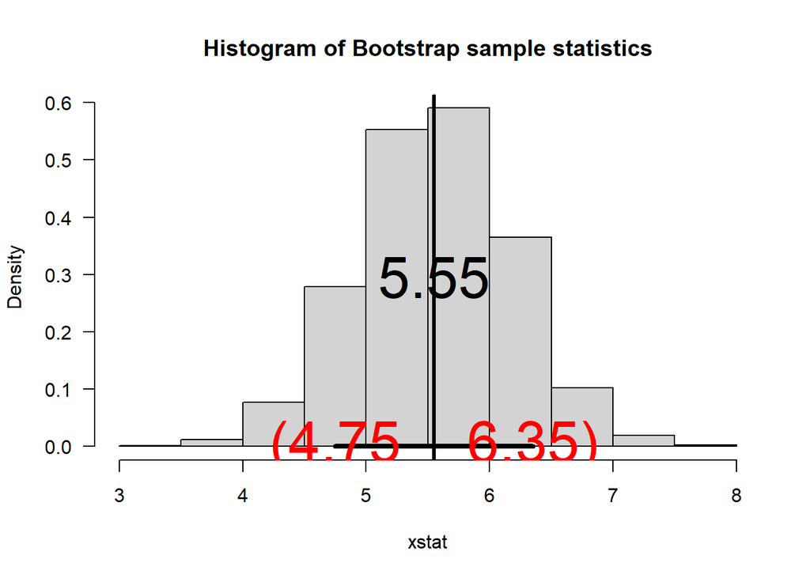

```r
bootstat=myboot(x=sam, fun="var", alpha=.2)
```

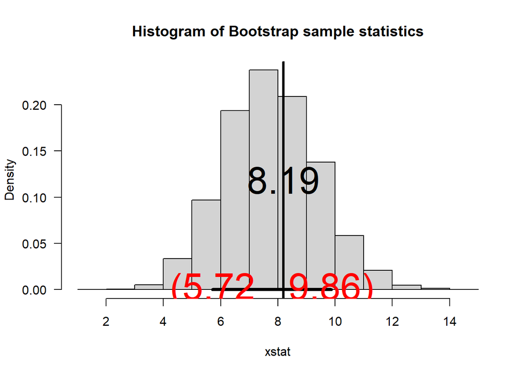

### F distribution

```r
set.seed(2); sam=rf(20, df1=5, df2=3)
bootstat=myboot(x=sam, fun="mean", alpha=.2)
```

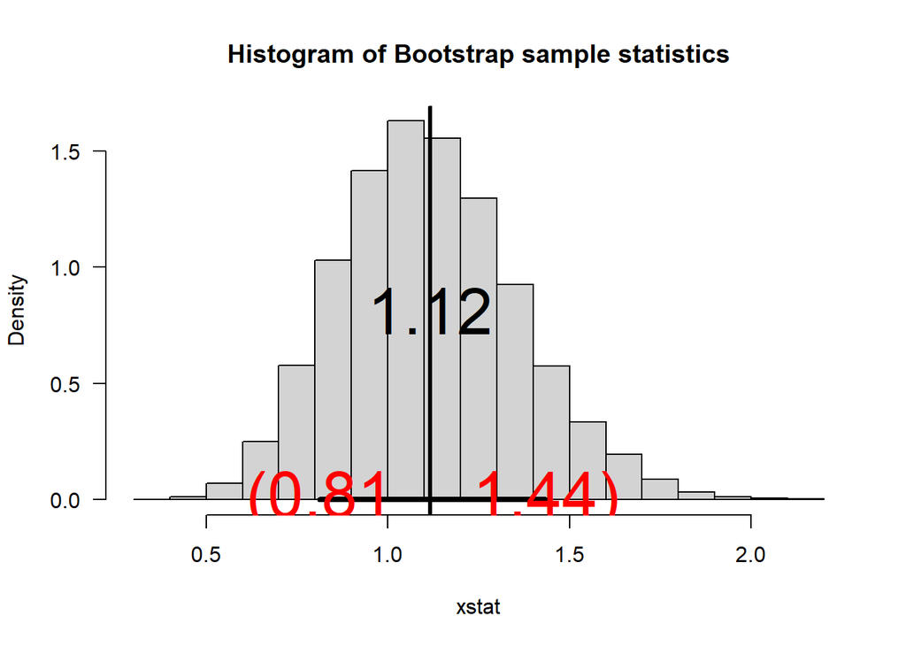

```r
bootstat=myboot(x=sam, fun="var", alpha=.2)
```

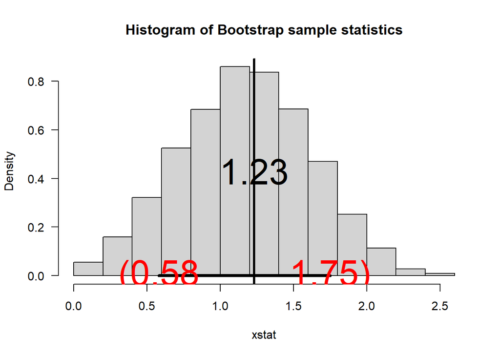

### Weibull Distribution

```r
set.seed(3); sam=rweibull(20, shape = 2, scale = 4)
bootstat=myboot(x=sam, fun="mean", alpha=.2)
```

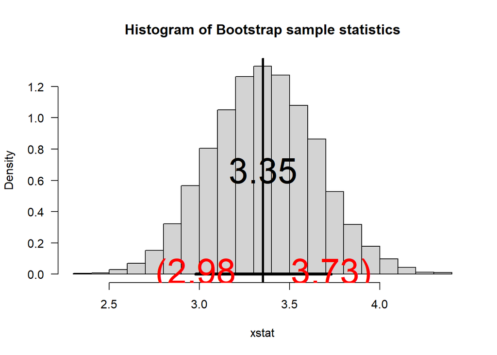

```r
bootstat=myboot(x=sam, fun="var", alpha=.2)
```

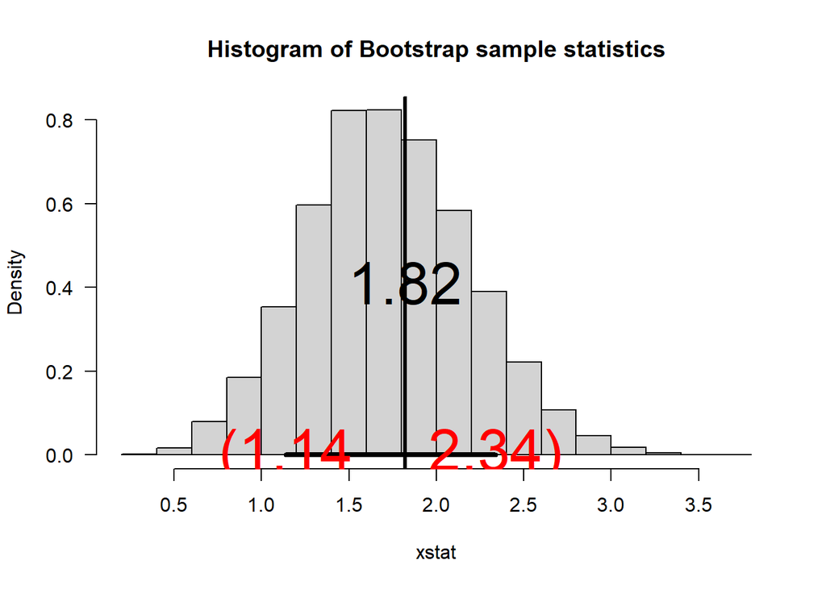

### Binomial Distribution

```r
set.seed(4); sam=rbinom(20, size = 100, p=.6)
bootstat=myboot(x=sam, fun="mean", alpha=.2)
```

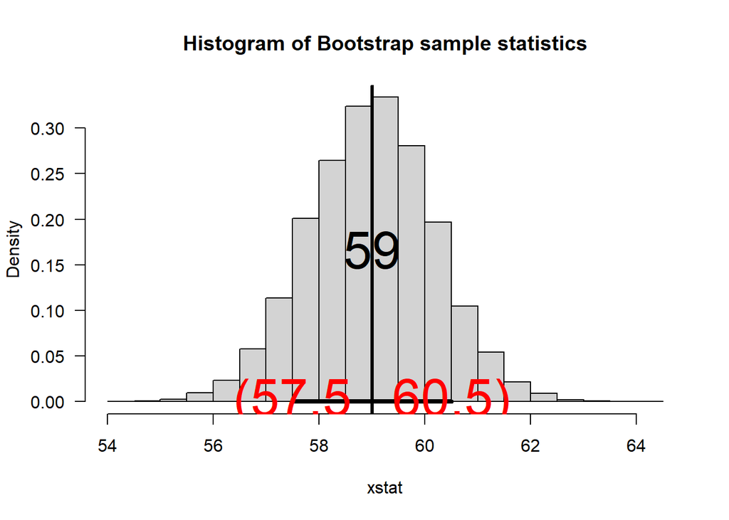

```r
bootstat=myboot(x=sam, fun="var", alpha=.2)
```

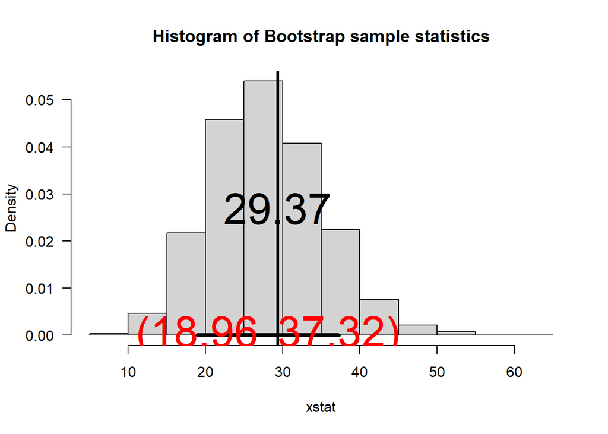

## Task 7

### Bootstrap of Normal for SD and IQR

```r
set.seed(68); sam=rnorm(20, mean=10, sd=4)

bootstat=myboot(x=sam, fun="sd")
```

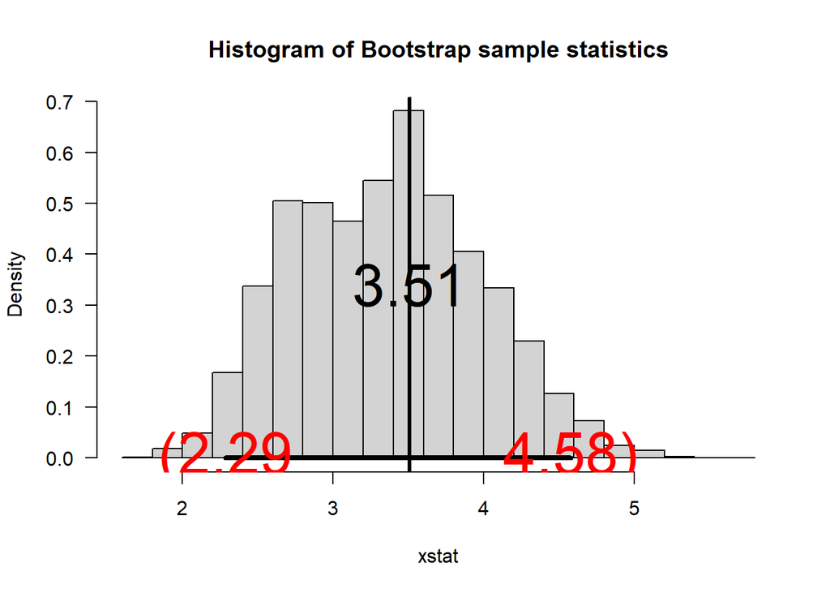

```r
bootstat=myboot(x=sam, fun="IQR")
```

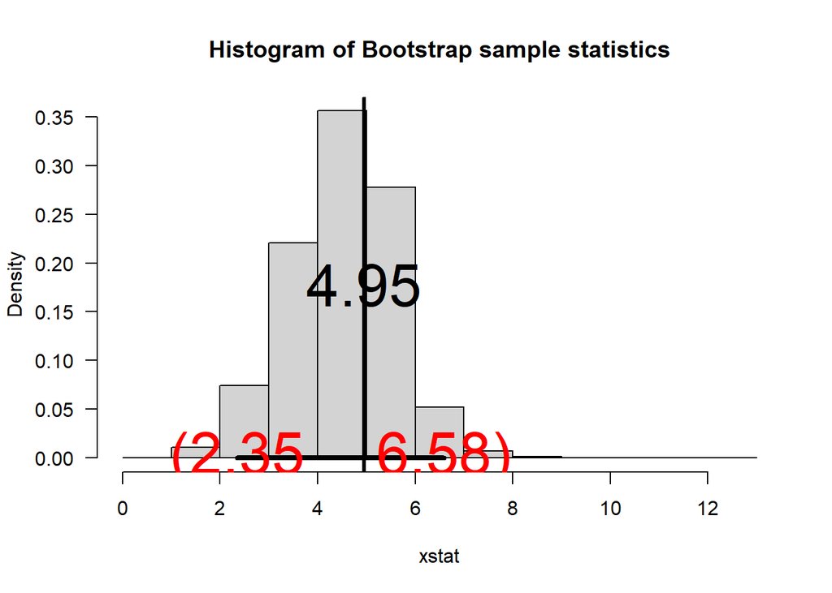

```r
alpha=0.05
z_alpha_2 = qnorm(1-(alpha/2), mean=0, sd=1)
z_alpha_2
```

```
## [1] 1.959964
```

```r
mean(sam)
```

```
## [1] 10.45931
```

### Verification

```r
bootstate=myboot(x=sam)
```

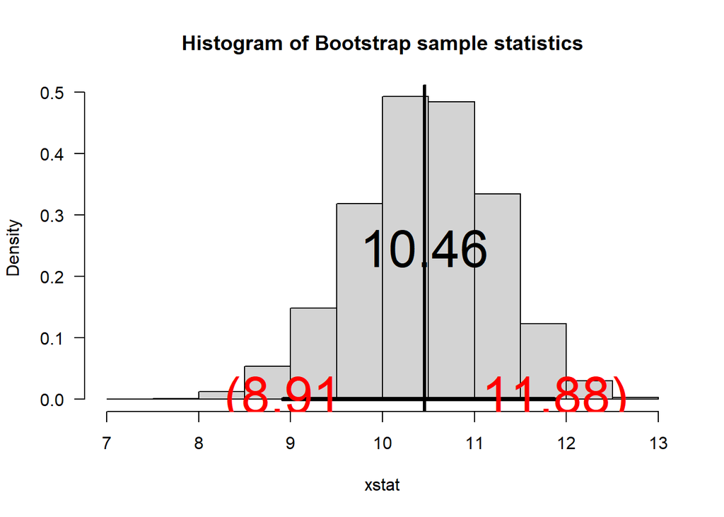

## Task 8

### myboot2 on package data

```r
library(MATH4753moom0002)

ciobj=MATH4753moom0002::myboot2(x=fire$DISTANCE)
```

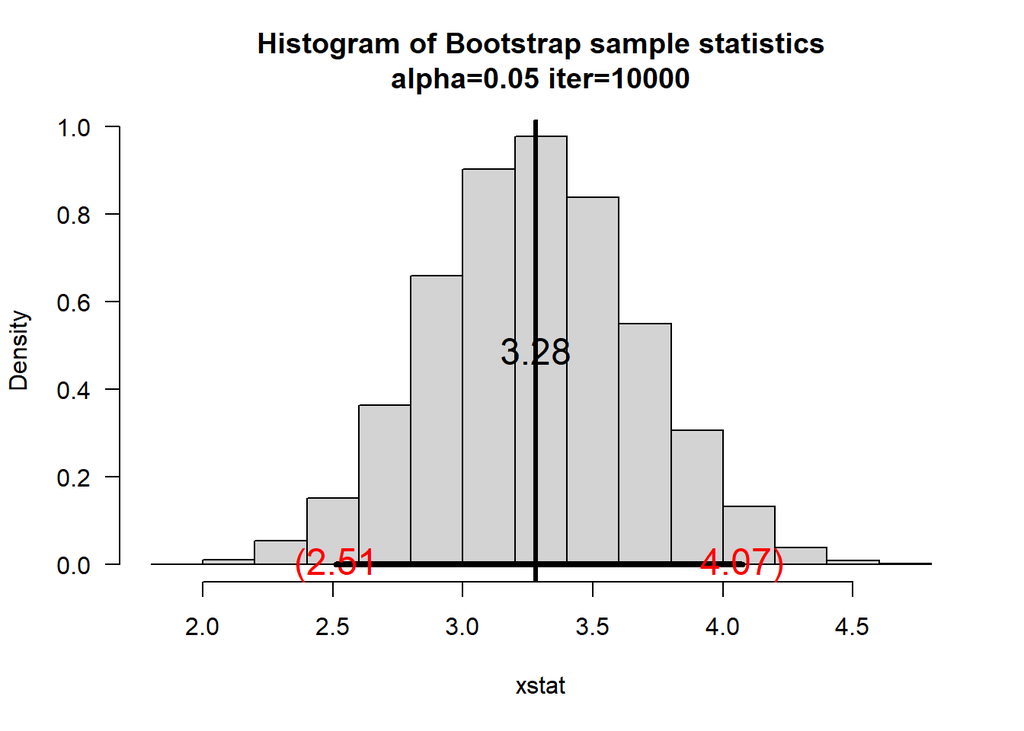